# Data Visualisation Notebook

### 3.6 Geometric Objects

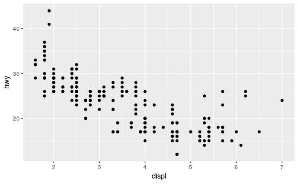

```r
# same variables on the axes but different geoms (geom is the geometrical object used to represent data)
# left: geom_point() plots points
ggplot(data = mpg) +
  geom_point(mapping = aes(x = displ, y = hwy))
```

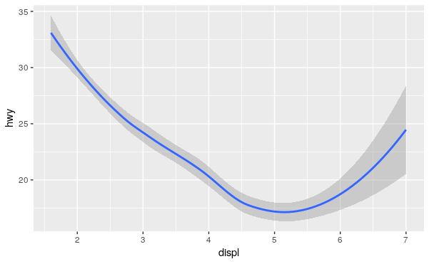

```r
# right: geom_smooth() plots a smooth line and a gray area for error(?)
ggplot(data = mpg) +
  geom_smooth(mapping = aes(x = displ, y = hwy))
```

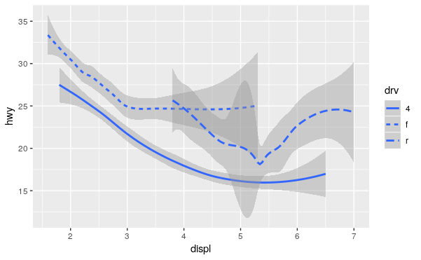

```r
# can add a 3rd variable like geom_point() but now the argument is specifically linetype
ggplot(data = mpg) +
  geom_smooth(mapping = aes(x = displ, y = hwy, linetype = drv))
```

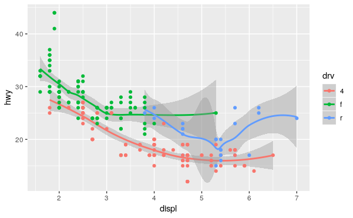

```r
# guessed at code to recreate the plot
# note: order matters
ggplot(data = mpg) +
  geom_smooth(mapping = aes(x = displ, y = hwy, color = drv)) +
  geom_point(mapping = aes(x = displ, y = hwy, color = drv))
```

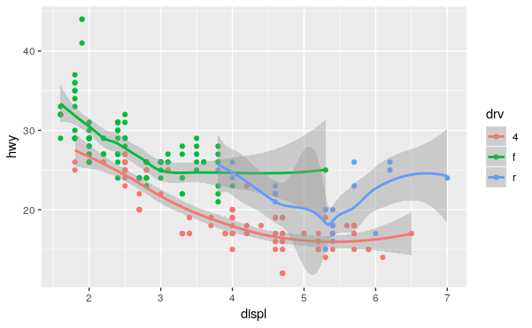

```r
# some points are darker or covered up by lines now
# this is the actual graph
ggplot(data = mpg) +
  geom_point(mapping = aes(x = displ, y = hwy, color = drv)) +
  geom_smooth(mapping = aes(x = displ, y = hwy, color = drv))
```

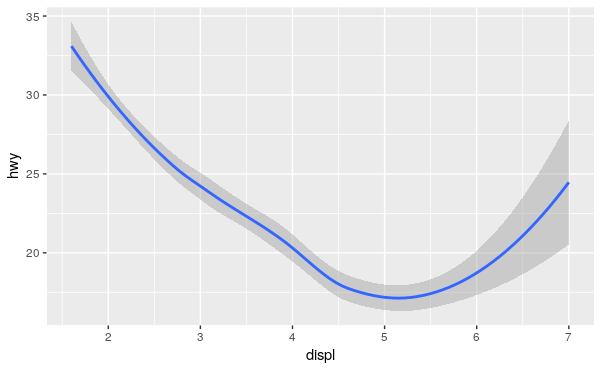

```r
# Left: the original plot using geom_smooth without a third variable
ggplot(data = mpg) +
  geom_smooth(mapping = aes(x = displ, y = hwy))
```

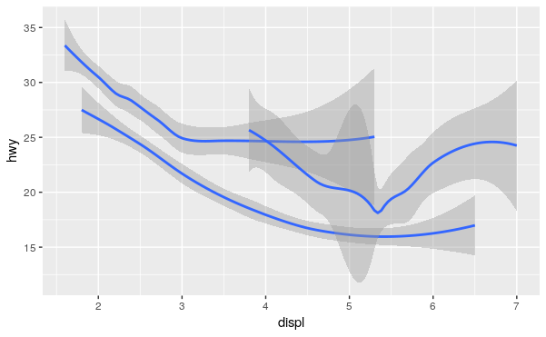

```r
# Middle: uses group // does not distinguish between the different groups
ggplot(data = mpg) +
  geom_smooth(mapping = aes(x = displ, y = hwy, group = drv))
```

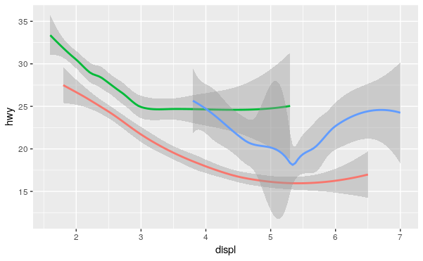

```r
# Right: distinguishes drv by color but does not show legend
# normally would automatically show legend unless specified show.legend= FALSE
ggplot(data = mpg) +
  geom_smooth(
    mapping = aes(x = displ, y = hwy, color = drv),
    show.legend = FALSE
  )
```

```r
# plots points then smooth line (like a couple chunks ago)
ggplot(data = mpg) +
  geom_point(mapping = aes(x = displ, y = hwy)) +
  geom_smooth(mapping = aes(x = displ, y = hwy))
```

```r
# simplifies the code so that you are only changing one variable in ggplot() even though it is the same as the previous chunk
# this is important because you can have errors through referencing multiple variables in different places
ggplot(data = mpg, mapping = aes(x = displ, y = hwy)) +
  geom_point() +
  geom_smooth()
```

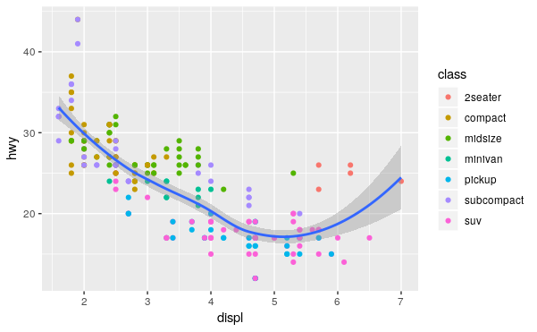

```r
# adds in color to just geom_point()
ggplot(data = mpg, mapping = aes(x = displ, y = hwy)) +
  geom_point(mapping = aes(color = class)) +
  geom_smooth()
```

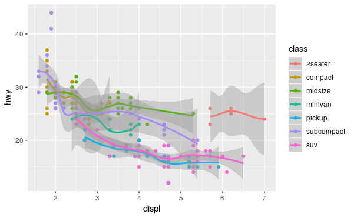

```r
# gets a lot of errors
# tried to map color for both point and smooth ~ not super helpful for visualizing data
ggplot(data = mpg, mapping = aes(x = displ, y = hwy, color = class)) +
  geom_point() +
  geom_smooth()
```

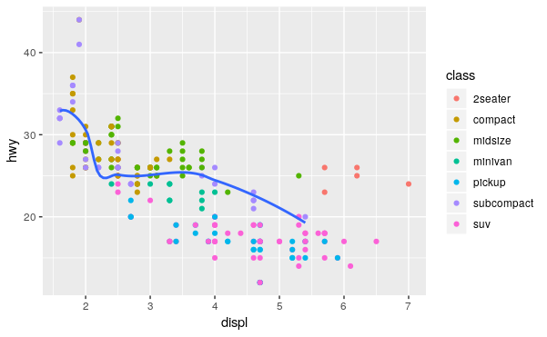

```r
# still using color for class in geom_point() only
# filtering only subcompact class of the smoothed data
ggplot(data = mpg, mapping = aes(x = displ, y = hwy)) +
  geom_point(mapping = aes(color = class)) +
  geom_smooth(data = filter(mpg, class == "subcompact"), se = FALSE)
```

```r
# se argument is the gray area around the line (confidence interval), TRUE by default
?geom_smooth
```

#### 3.6.1 Exercises

```
What geom would you use to draw a line chart? A boxplot? A histogram? An area chart?
```

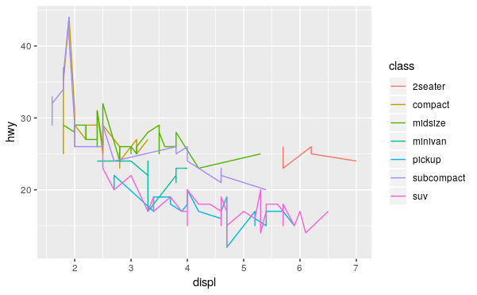

```r
# line chart
ggplot(data = mpg) +
  geom_line(mapping = aes(x = displ, y = hwy, color = class))
```

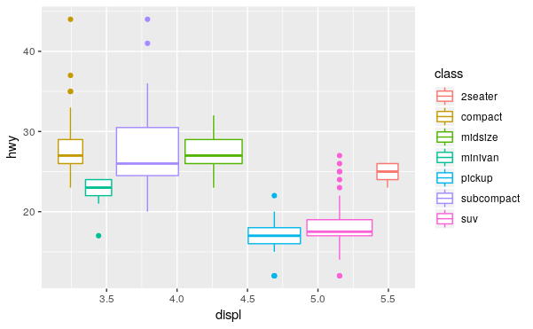

```r
# boxplot
ggplot(data = mpg) +
  geom_boxplot(mapping = aes(x = displ, y = hwy, color = class))
```

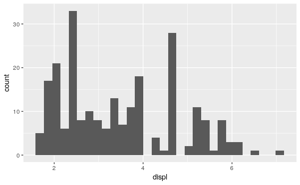

```r
# histogram
ggplot(data = mpg) +
  geom_histogram(mapping = aes(x = displ))
```

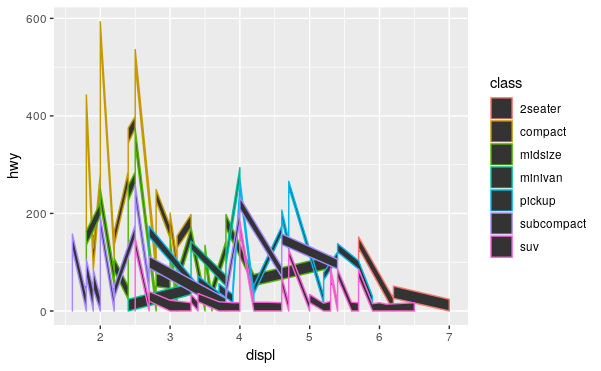

```r
# area chart
ggplot(data = mpg) +
  geom_area(mapping = aes(x = displ, y = hwy, color = class))
```

```
Run this code in your head and predict what the output will look like. Then, run the code in R and check your predictions.
```

- I predict that this code will plot displ and hwy as points, differing the drv by color. The smooth lines will also be divided drv by color and will not show the gray area around the lines

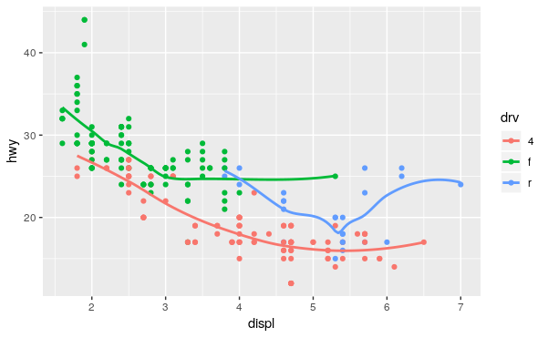

```r
# Prediction = TRUE
ggplot(data = mpg, mapping = aes(x = displ, y = hwy, color = drv)) +
  geom_point() +
  geom_smooth(se = FALSE)
```

```
What does show.legend = FALSE do? What happens if you remove it?
Why do you think I used it earlier in the chapter?
```

- show.legend = FALSE does not display the legend.
- If you remove this, it defaults to show.legend = TRUE and shows the legend
- It was used earlier in the chapter because the other graphs did not have a legend and having a legend slightly shrinks the x axis (visual evenness)

  What does the se argument to geom_smooth() do?
- se argument is in reference to the gray area near the line. It signifies the confidence interval and the se argument specifies if it is visible on the graph (TRUE/FALSE)

  Will these two graphs look different? Why/why not?
- these graphs will not look different because if the mapping is specified in ggplot() then it applies to all the functions following (+)

```r
ggplot(data = mpg, mapping = aes(x = displ, y = hwy)) +
  geom_point() +
  geom_smooth()
```

```r
ggplot() +
  geom_point(data = mpg, mapping = aes(x = displ, y = hwy)) +
  geom_smooth(data = mpg, mapping = aes(x = displ, y = hwy))
```

```
Recreate the R code necessary to generate the following graphs.
```

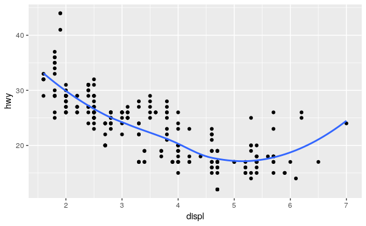

```r
# top left: no confidence interval, both a line and points
# x axis is displ and y axis is hwy
ggplot(data = mpg, mapping = aes(x = displ, y = hwy)) +
  geom_point() +
  geom_smooth(se = FALSE)
```

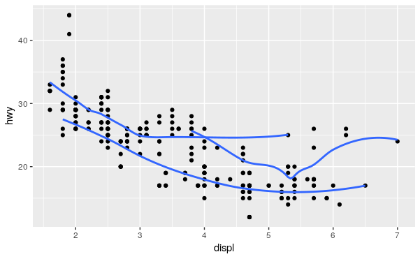

```r
# top right: same as the previous graph, except the line is split into 3 (we've seen this previously as drv)
# drv line is split as group because there is no discerning legend or color (linetype etc)
ggplot(data = mpg, mapping = aes(x = displ, y = hwy)) +
  geom_point() +
  geom_smooth(mapping = aes(group = drv), se = FALSE)
```

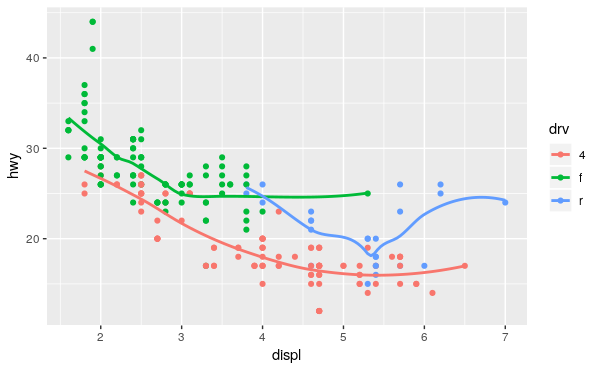

```r
# mid left: both the lines and points have discerning color by drv, no confidence interval visible still
ggplot(data = mpg, mapping = aes(x = displ, y = hwy, color = drv)) +
  geom_point() +
  geom_smooth( se = FALSE)
```

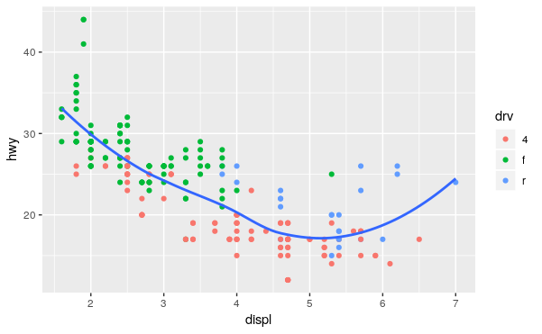

```r
# mid right: color difference for points, just 1 line though.
# specify color in geom_point() but not in geom_smooth()
# still no confidence interval (se = FALSE)
ggplot(data = mpg, mapping = aes(x = displ, y = hwy)) +
  geom_point(mapping = aes(color = drv)) +
  geom_smooth(se = FALSE)
```

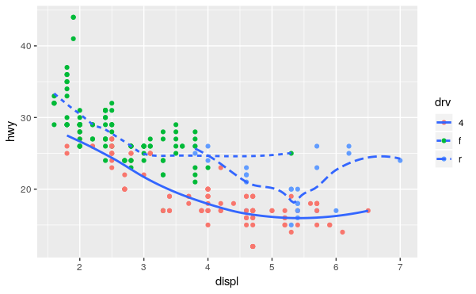

```r
# bottom left: points different through color (drv), line different through line type (drv)
# no confidence interval
ggplot(data = mpg, mapping = aes(x = displ, y = hwy)) +
  geom_point(mapping = aes(color = drv)) +
  geom_smooth(mapping = aes(linetype = drv), se = FALSE)
```

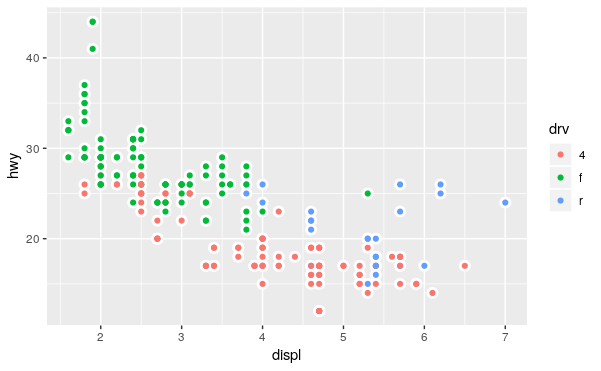

```r
# bottom right: order matters
# white points behind the color points separated by drv
# white points are visible from behind color points, must be larger - stroke = 2
# specify color and stroke for first geom_point()
# mapping for drv, separate by color for second geom_point()
# if done in the wrong order, white dots, no color
ggplot(data = mpg, mapping = aes(x = displ, y = hwy)) +
  geom_point(color = "white", stroke = 2) +
  geom_point(mapping = aes(color = drv))
```

### 3.7 Statistical Transformations

```r
# plots cut as x axis and freq/count as y axis
ggplot(data = diamonds) +
  geom_bar(mapping = aes(x = cut))
```

```r
# same plot different command; stat_count()
ggplot(data = diamonds) +
  stat_count(mapping = aes(x = cut))
```

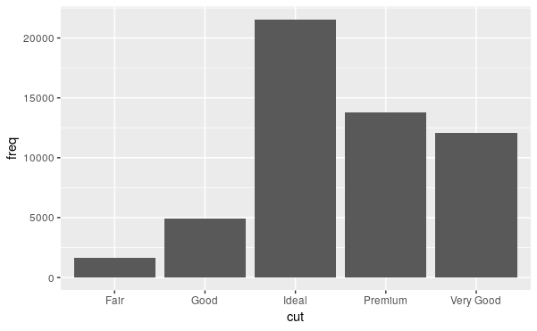

```r
# again, same concept, different method, different data too
demo <- tribble(
  ~cut,         ~freq,
  "Fair",       1610,
  "Good",       4906,
  "Very Good",  12082,
  "Premium",    13791,
  "Ideal",      21551
)
ggplot(data = demo) +
  geom_bar(mapping = aes(x = cut, y = freq), stat = "identity")
```

```r
# using proportion instead of default mapping
# note the y axis (and compare to the previous diamond cut plots )
ggplot(data = diamonds) +
  geom_bar(mapping = aes(x = cut, y = ..prop.., group = 1))
```

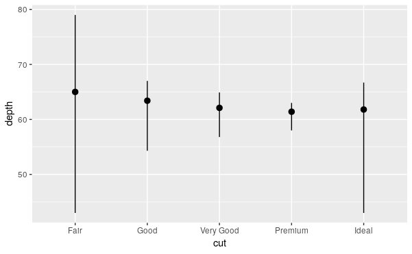

```r
# maps specific x (cut) and y (depth)
# specifies the y axis bounds using data information
# plots the median of each x axis value
ggplot(data = diamonds) +
  stat_summary(
    mapping = aes(x = cut, y = depth),
    fun.ymin = min,
    fun.ymax = max,
    fun.y = median
  )
```

```r
# lots of stats to use in graphing - check em out
?stat_bin
```

#### 3.7.1 Exercises

```
What is the default geom associated with stat_summary()? How could you rewrite the previous plot to use that geom function instead of the stat function?
```

```
Ignoring unknown parameters: ymin, ymax
```

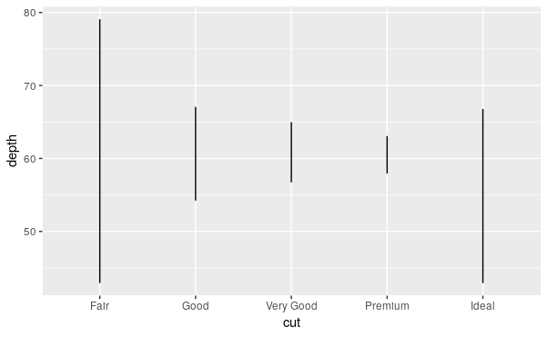

```r
?stat_summary
# default connection between geom_histogram/geom_freqpoly
?geom_crossbar
# this is as close as I got to the original graph using geom_line()
ggplot(data = diamonds, mapping = aes(x = cut, y = depth)) +
  geom_line(ymin = min(diamonds$depth), ymax = max(diamonds$depth))
```

```
What does geom_col() do? How is it different to geom_bar()?
```

```r
# plots cut as x axis and freq/count as y axis
ggplot(data = diamonds) +
  geom_bar(mapping = aes(x = cut))
```

```r
# Need to specify a y axis - err
ggplot(data = diamonds) +
  geom_col(mapping = aes(x = cut))
```

```
Error in pmin(y, 0) : object 'y' not found
```

```
Most geoms and stats come in pairs that are almost always used in concert. Read through the documentation and make a list of all the pairs. What do they have in common?

What variables does stat_smooth() compute? What parameters control its behaviour?

In our proportion bar chart, we need to set group = 1. Why? In other words what is the problem with these two graphs?
```

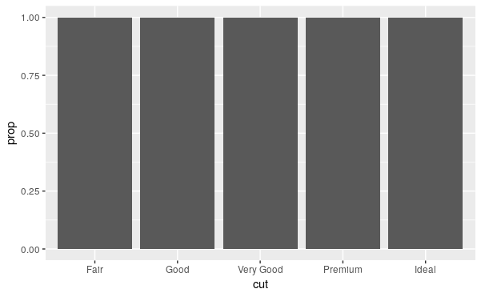

```r
    ggplot(data = diamonds) +
      geom_bar(mapping = aes(x = cut, y = ..prop..))
```

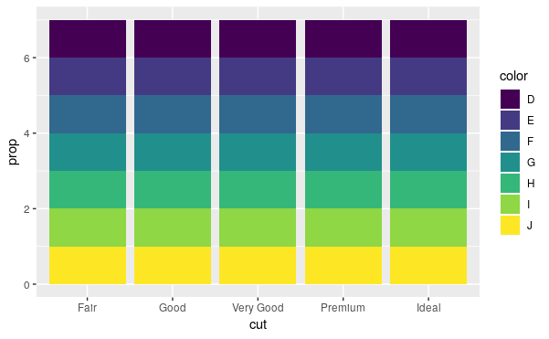

```r
    ggplot(data = diamonds) +
      geom_bar(mapping = aes(x = cut, fill = color, y = ..prop..))
```

```r
    ggplot(data = diamonds) +
      geom_bar(mapping = aes(x = cut, y = ..prop.., group = 1))
```

```r
    ggplot(data = diamonds) +
      geom_bar(mapping = aes(x = cut, fill = color, y = ..prop.., group = 1))
```

### 3.8 Position adjustments

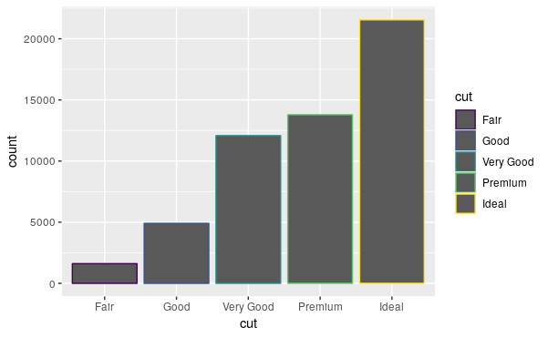

```r
ggplot(data = diamonds) +
  geom_bar(mapping = aes(x = cut, colour = cut))
```

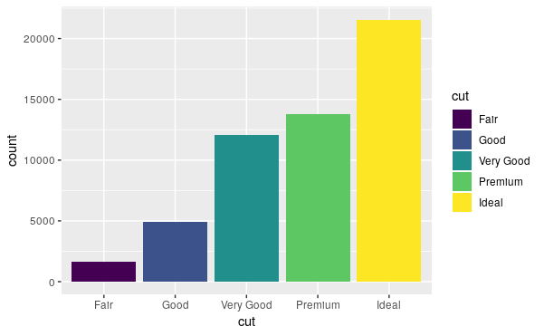

```r
ggplot(data = diamonds) +
  geom_bar(mapping = aes(x = cut, fill = cut))
```

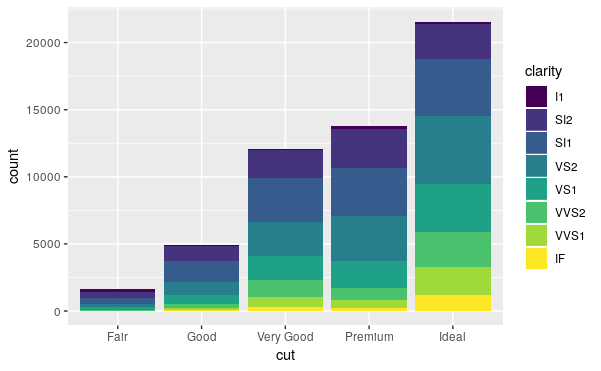

```r
ggplot(data = diamonds) +
  geom_bar(mapping = aes(x = cut, fill = clarity))
```

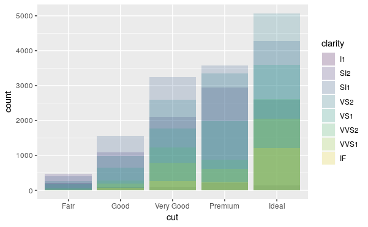

```r
ggplot(data = diamonds, mapping = aes(x = cut, fill = clarity)) +
  geom_bar(alpha = 1/5, position = "identity")
```

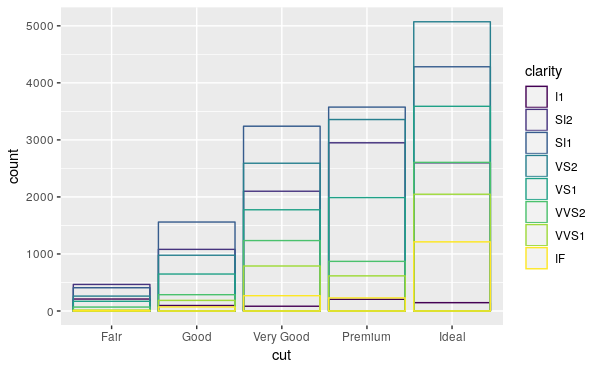

```r
ggplot(data = diamonds, mapping = aes(x = cut, colour = clarity)) +
  geom_bar(fill = NA, position = "identity")
```

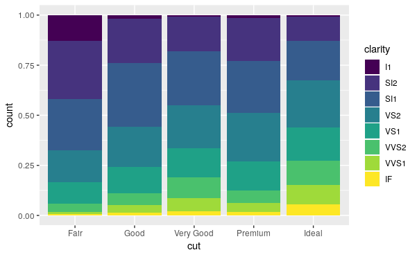

```r
ggplot(data = diamonds) +
  geom_bar(mapping = aes(x = cut, fill = clarity), position = "fill")
```

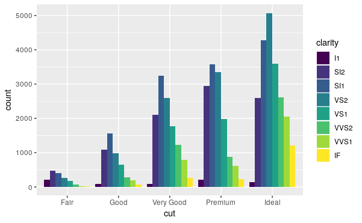

```r
ggplot(data = diamonds) +
  geom_bar(mapping = aes(x = cut, fill = clarity), position = "dodge")
```

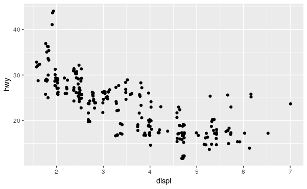

```r
ggplot(data = mpg) +
  geom_point(mapping = aes(x = displ, y = hwy), position = "jitter")
```

#### 3.8.1 Exercises

```
What is the problem with this plot? How could you improve it?
```

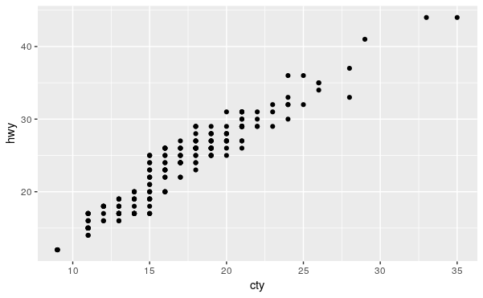

```r
    ggplot(data = mpg, mapping = aes(x = cty, y = hwy)) +
      geom_point()
```

```
What parameters to geom_jitter() control the amount of jittering?

Compare and contrast geom_jitter() with geom_count().

What’s the default position adjustment for geom_boxplot()? Create a visualisation of the mpg dataset that demonstrates it.
```